# 550_Chi-Square Tests

## Chi-Square Tests

For more detail, see LSR Ch 12 [here](https://learningstatisticswithr.com/book/chisquare.html)

OpenStaxStats Ch. 11 [here](https://assets.openstax.org/oscms-prodcms/media/documents/IntroductoryStatistics-OP_i6tAI7e.pdf)

## GOF Example: Birthdays

In his book *Outliers*, Malcolm Gladwell suggests that a hockey player’s birth month has a big influence on his chance to make it to the highest levels of the game. Specifically, since January 1 is the cutoff date for youth leagues in Canada (where many National Hockey League players come from), players born in January will be competing against players up to 12 months younger. The older players tend to be bigger, stronger, and more coordinated and hence get more playing time and more coaching and have a better chance of being successful.

To see if birth date is related to success (judged by whether a player makes it into the NHL), a random sample of 80 NHL players from a recent season was selected and their birthdays were recorded. Overall, 32 were born in the first quarter of the year, 20 in the second quarter, 16 in the third quarter, and 12 in the fourth quarter.

Do these data provide convincing evidence that the birthdays of NHL players are not uniformly distributed throughout the year?

### (a) What type of data is this? How many groups/samples were taken? Store as `observed`.

```r
observed <- c(32, 20, 16, 12)
```

### (b) Why can’t we use any of the significance tests that we’ve learned so far? they are quantitative

### (c) Is there some evidence that birthdays are not uniformly distributed?

### (d) What are two statistical explanations (or models) for this evidence?

1. birthdays in the ngl are truly inuformly dist; our sample simply gave us unequal numbers due to random chance.
2. Birthdays in the nhl are not uiformly dist.

### (e) State the hypotheses that Malcolm would test.

Null: Birthdays are unif dist

Alternative: birthdays in the nhl are not uniformly dist.

*Another option…*

Null: p(q1) = p(q2)…where the p=.25 the prop of all nhl players born in that quarter.

Alternative: at least one p does not equal the others.

### (f) If birthdays are uniformly distributed, calculate the *expected count* $E_i$ for each of the possible outcomes. Store as `expected`.

```r
expected <- c(20, 20, 20, 20) #roughly
```

### (g) There are three conditions to check for a chi-square test.

$$\chi^2$$

- Is the data from a random sample or random assignment? we say yes
- Are all expected counts are greater than 5? yes
- Can the observations be considered independent (or check 10% condition): not really, since we are smpling w/o replacement. as long as the pop is large, it shouldn’t change succss of finding
- 10%(all nhl players ) > 80

Since the conditions are met, we will use a *chi-square goodness-of-fit test* (“GOF”).

### ————————————————————————

### (h) Calculate the value of the chi-square test statistic manually.

```r
# Store observed
observed <- c(32, 20, 16, 12)

# Store expected
expected <- c(20, 20, 20, 20)              # (sample size) * probability = 80*0.25 = 20

# Find the "deviation" from expected
observed - expected
```

```
[1] 12  0 -4 -8
```

```r
# Square to remove negatives
(observed - expected)^2
```

```
[1] 144   0  16  64
```

```r
# Divide to find weighted contribution
(observed - expected)^2 / expected
```

```
[1] 7.2 0.0 0.8 3.2
```

```r
# Sum up to find the test statistic

sum((observed - expected)^2 / expected)
```

```
[1] 11.2
```

Why “weighted” contributions?

| Observed | Expected | $(O-E)^2$ | $\fra c {(O-E)^2}{E}$ |
| --- | --- | --- | --- |
| 0 | 10 | 100 | 100/10 = 10 |
| 990 | 1000 | 100 | 100/1000 = 0.1 |

$$\chi^2=\frac{(O_1-E_1)^2}{E_1} +
\frac{(O_2-E_2)^2}{E_2} + \frac{(O_3-E_3)^2}{E_3} +
\frac{(O_4-E_4)^2}{E_4}\\
\chi^2=\Sigma\frac{(O_i-E_i)^2}{E_i} \\
\chi^2=\Sigma\frac{(observed - expected)^2}{expected}$$

If you like to see work written out…

$$\chi^2=\frac{(32-20)^2}{20}+\frac{(20-20)^2}{20}+\frac{(16-20)^2}{20}+\frac{(12-20)^2}{20}=11.2$$

### ————————————————————————

### (i) For a chi-square GOF test, the degrees of freedom is number of categories minus 1: $df = k - 1$. (not sample size!)

df = k - 1

df = c - 1

df = n - 1

Our categories: Q1, Q2, Q3, Q4

```r
df <- 4 -1
```

Visual of $\chi_3^2$

```r
# Set the degrees of freedom
df <- 3

# Generate random numbers from chi-square distribution
chi_sq_data <- rchisq(1000, df)

# Calculate density estimates
density_est <- density(chi_sq_data)

# Plot the density curve
plot(density_est$x,
     density_est$y,
     main = "Chi-square Distribution (df = 3)",
     xlab = "Simulated Chi-Square Values",
     ylab = "Density",
     col = "white",
     ylim = c(0, 0.30),
     las = 1)

# Add theoretical density curve
curve(dchisq(x, df), add = TRUE, col = "blue", lwd = 2)
```

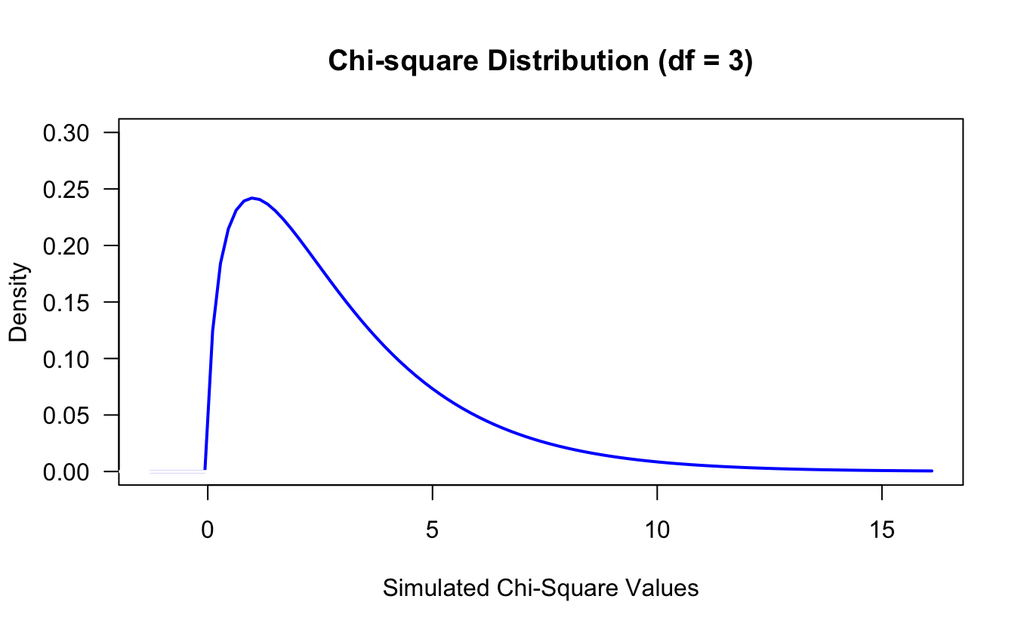

```r
# Hide values < 0 on distribution
segments(-5, 0, 0, 0, col = "white", lwd = 2)
```

### (j) Use a chi-square table or `pchisq()` to find the P-value.

If conditions are met (i.e., all $E_i \ge 5$), then the test statistic follows a chi-square distribution.

[Tables](https://www.openintro.org/go/?id=stat_prob_tables_normal_t_chisq&referrer=/book/os/index.php)

Prefixes: r, p, q, d

```r
#table gave p value bn .01 and .02
pchisq(q = 11.2, df = 3, lower.tail = FALSE)
```

```
[1] 0.01069213
```

### (k) What does the P-value mean in this context? In other words, “interpret” the P-value.

### ————————————————————————

assuming nhl player birhdays are unif dist, ther is s a.0107 prob that we observe sample datae like we did or more ext just due to sampleing variable.

assuming that nhl player birth are unif dist, there is a .0107 prob that we obs a test stat of 11.2 or more just due to sampling variablity.

### (l) What conclusion would you make?

1. since p value = 0107 is less than alpha = .05
2. we reject null
3. we have convin evid that all nhl player birth are not uniform dist across the quarters of the year. (for the season in question)

| Comparison | $H_0$ | $H_a$ | Sta tistically Si gnificant? | Possible Error? |
| --- | --- | --- | --- | --- |
| `P-valu e < alpha` | Reject $H_0$ | Find convincing evidence for $H_a$ | yes | Type I |
| `P-valu e > alpha` | Do not reject $H_0$ “fail to reject” | Do not find convincing evidence for $H_a$ | no | Type II |

Remember, the random sample gave us “some” evidence (initial, preliminary) that birthdays were not uniformly distributed, this low P-value tells us that this data is unlikely to have occurred simply by chance.

### (m) Use the `goodnessOfFit()` function in the `lsr` package to find the chi-square test statistic and P-value.

```r
# Install & load the lsr package

install.packages("lsr")
library(lsr)

#lsr::goodnessOfFitTest
```

What are the problems here?

```r
goodnessOfFitTest(x = as.factor(observed), p = c(.25, 25, .25, .25))
```

[output not shown]

```
     Chi-square test against specified probabilities

Data variable:   as.factor(observed)

Hypotheses:
   null:        true probabilities are as specified
   alternative: true probabilities differ from those specified

Descriptives:
   observed freq. expected freq. specified prob.
12              1     0.03883495     0.009708738
16              1     3.88349515     0.970873786
20              1     0.03883495     0.009708738
32              1     0.03883495     0.009708738

Test results:
   X-squared statistic:  73.508
   degrees of freedom:  3
   p-value:  <.001
```

We have to use the table of **counts** to create what the **data** may look like.

```r
nhl_as_data <- c(rep(as.factor("Q1"), 32),
                 rep(as.factor("Q2"), 20),
                 rep(as.factor("Q3"), 16),
                 rep(as.factor("Q4"), 12)
)

lsr::goodnessOfFitTest(x = nhl_as_data, p = c(.25, .25, .25, .25))
```

```
     Chi-square test against specified probabilities

Data variable:   nhl_as_data

Hypotheses:
   null:        true probabilities are as specified
   alternative: true probabilities differ from those specified

Descriptives:
   observed freq. expected freq. specified prob.
Q1             32             20            0.25
Q2             20             20            0.25
Q3             16             20            0.25
Q4             12             20            0.25

Test results:
   X-squared statistic:  11.2
   degrees of freedom:  3
   p-value:  0.011
```

### (n) Give a brief report of findings.

For more detail on what should be included, see [here](https://learningstatisticswithr.com/book/chisquare.html#chisqreport).

Of the 80 NHL players randomly selected for this study, 32 were born in the first quarter of the year, 20 in the second quarter, 16 in the third quarter, and 12 in the fourth quarter. A chi-square goodness of fit test was conducted to test whether birthdays of NHL players are not uniformly distributed throughout the year.

The results were significant $\chi^2(3)$ = 11.2, $p < 0.05$ , suggesting that birthdays of NHL players are *not uniformly distributed* throughout the year.

A much larger than expected number of players were born in the first quarter.

### ————————————————————————

## GOF Example: Racial Stereotypes

The authors of the paper *Racial Stereotypes in Children’s Television Commercials* (*Journal of Advertising Research*) counted the number of times that characters of different ethnicities appeared in commercials aired on Philadelphia TV stations, results in the data in the table below. [SDA5e, 633]

| Ethnicity | African-American | Asian | Caucasian | Hispanic | Total |
| --- | --- | --- | --- | --- | --- |
| Frequency | 57 | 11 | 330 | 6 | 404 |

The table below shows the proportion of the US population falling into each of these four ethnic groups, based on the Census around the time of the commercials.

| Ethnicity | African-American | Asian | Caucasian | Hispanic |
| --- | --- | --- | --- | --- |
| Census Proportion | 0.177 | 0.032 | 0.734 | 0.057 |

Do the data provide sufficient evidence to conclude that the proportions appearing in commercials are not the same as the census proportions? Test the relevant hypotheses using a significance level of 0.01.

```r
# Store observed counts
observed <- c(57, 11, 330, 6)

# Store null probabilities
nullprobs <- c (0.177, .032, .734, .057)

# Store sample size
commercial_n <- sum(observed)

# Calculate the expected counts
comm_expected <- commercial_n * nullprobs
```

### (a) What hypotheses are we testing?

H0 - propo apperaing in comm are the same as the censu prop

Ha - the prop appearing in commer are not the same as the censu prop.

### (b) Check the conditions

1. it’s unclear if this data comes from a random sample of all comercials airing in phil. we should be cautious about general to the pop.
2. all expected counts (71.5, 12.9, 296.5, 23)
3. we assume there are more than 4040 char in the pop.

### (c) Calculate $\chi^2$ test statistic and P-value.

Hint: Check the documentation of `?lsr::goodnessOfFitTest` on how to deal with using probabilities that aren’t all equally likely (i.e. uniformly distributed).

```r
#
#sum((observed - expected)^2 / expected)
sum((observed - comm_expected)^2 / comm_expected)
```

```
[1] 19.59872
```

```r
#?lsr::goodnessOfFitTest
comm_data <- c(rep("African Americans", 57),
               rep("Asian", 11),
               rep("Caucasian", 330),
               rep("Hispanic", 6))

goodnessOfFitTest(x = as.factor(comm_data), p = nullprobs)
```

```
     Chi-square test against specified probabilities

Data variable:   as.factor(comm_data)

Hypotheses:
   null:        true probabilities are as specified
   alternative: true probabilities differ from those specified

Descriptives:
                  observed freq. expected freq. specified prob.
African Americans             57         71.508           0.177
Asian                         11         12.928           0.032
Caucasian                    330        296.536           0.734
Hispanic                       6         23.028           0.057

Test results:
   X-squared statistic:  19.599
   degrees of freedom:  3
   p-value:  <.001
```

```r
# Calculate the exact P-value

pchisq(q = 19.599, df = 3, lower.tail = FALSE)
```

```
[1] 0.0002055213
```

### (d) Interpret the P-value in context.

assum the prop of ethn in comm airing in phil equal to the corresp census prop there’s is a .0002 prob that we would obser a stat of 19.599 just due to sampling variabli

### (e) Conclude the test.

1. since .0002 < .01
2. we reject the null
3. we find convin evid that the prop of ethn appearing in comm in the phil aared during this time span.

### (f) Which ethnicity made the biggest contribution to the chi-squared test statistic?

```r
#
(observed - comm_expected)^2 / comm_expected
```

```
[1]  2.9434758  0.2875297  3.7764025 12.5913142
```

### Manual calculation and visualization

$$\chi^2=\frac{(57-71.508)^2}{71.508}+\frac{(11-12.928)^2}{12.928}+\frac{(330-296.536)^2}{296.536}+\frac{(6-23.028)^2}{23.028}$$

```r
# Set the degrees of freedom
df <- 3

# Generate random numbers from chi-square distribution
chi_sq_data <- rchisq(1000, df)

# Calculate density estimates
density_est <- density(chi_sq_data)

# Plot the density curve
plot(density_est$x,
     density_est$y,
     main = "Chi-square Distribution (df = 3)",
     xlab = "Simulated Chi-Square Values",
     ylab = "Density",
     col = "white",
     ylim = c(0, 0.30),
     las = 1)

# Add theoretical density curve
curve(dchisq(x, df), add = TRUE, col = "red", lwd = 2)
```

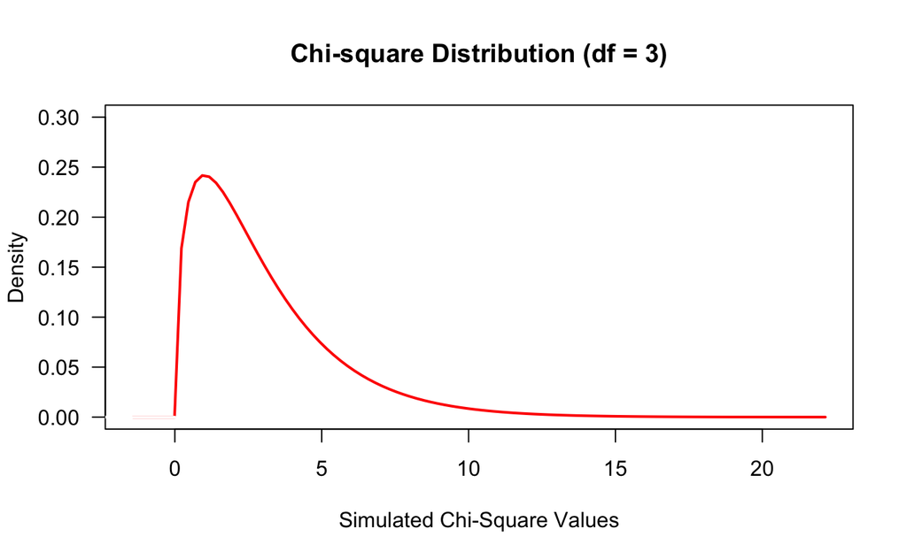

```r
# Hide values < 0 on distribution
segments(-5, 0, 0, 0, col = "white", lwd = 2)
```

### ————————————————————————

## Introducing Chi-Square Tests with Two-Way Tables

GOF Example 1:

| Birth Date | Q1 | Q2 | Q3 | Q4 | Total |
| --- | --- | --- | --- | --- | --- |
| Frequency | 32 | 20 | 16 | 12 | 80 |

GOF Example 2:

“One-Way” Tables

| Ethnicity | African-American | Asian | Caucasian | Hispanic | Total |
| --- | --- | --- | --- | --- | --- |
| Frequency | 57 | 11 | 330 | 6 | 404 |

What type of data? How many groups?

Two Types

1. **Test for Homogeneity (TOH)**
- Does this categorical variable have the same distribution across these different populations (or treatment groups)?
2. **Test for Association (TOA)**
- Aka, Test for Independence (TOI)
- Are these two categorical variables associated or are they independent of each other in this one population?

Some courses and textbooks don’t make a big deal about this difference!

| Type of Test | Number of Groups or Populations | Number of Categorical Variables |
| --- | --- | --- |
| Chi-Square Goodness-of-Fit Test | 1 | 1 |
| Chi-Square Test of Homogeneity | 2+ | 2 |
| Chi-Square Test of Association (or Independence) | 1 | 2 |

What’s different? Hypotheses; DF formula; expected counts formula

What’s the same? Test statistic formula; chi-square distribution; find the P-value; concluding

## ————————————————————————

## Example: Anger and Heart Disease

(from TPS7, 776-77)

Are people who are prone to sudden anger more likely to develop heart disease? A prospective observational study followed a random sample of 8,474 people with normal blood pressure for about 4 years. All the individuals were free of heart disease at the beginning of the study. Each person took the Spielberger Trait Anger Scale Test, which measures how prone a person is to sudden anger. The researchers then categorized each person’s anger level as Low, Moderate, or High based on their test score. They also recorded whether each individual developed coronary heart disease. This classification includes people who had heart attacks and those who needed medical treatment for heart disease. The two-way table summarizes the results of the study.

|  | Low | Moderate | High | Total |
| --- | --- | --- | --- | --- |
| **Yes CHD** | 53 | 110 | 27 | 190 |
| **No CHD** | 3057 | 4621 | 606 | 8284 |
| **Total** | 3110 | 4731 | 633 | 8474 |

Do the data provide convincing evidence at the $\alpha = 0.10%$ level of an association between anger level and heart disease status for people with normal blood pressure?

### (a) What is a “prospective” observational study? Why use an observational study and not a randomized experiment?

### (b) What is the explanatory variable and what is the response variable?

### (c) What type of significance test would be appropriate here?

### (d) Input the data into a matrix.

```r
# Input the counts (but not the totals!)
anger_counts <- c(53, 110, 27, 3057, 4621, 606)

# Create the matrix
#chd_anger_table <- matrix(anger_counts, nrow = 2, ncol = 3, byrow = TRUE)

# Name rows and columns
#rownames(chd_anger_table) <- c("Yes CHD", "No CHD")
#colnames(chd_anger_table) <- c("Low", "Moderate", "High")

# Show the table
print(chd_anger_table)
```

```r
# Alternate approach: bind values by row

data_by_rows <- rbind(c(53, 110, 27), c(3057, 4621, 606))

#rownames(data_by_rows) <- c("Yes CHD", "No CHD")
#colnames(data_by_rows) <- c("Low", "Moderate", "High")

data_by_rows
```

### (e) Calculate the conditional distribution of CHD event by anger level.

```r
proportions(chd_anger_table, margin = 2)

#round(proportions(chd_anger_table, margin = 2), 3)*100
```

### (f) Does the conditional distribution give *some* evidence of an association?

### (g) What are two explanations (or models) for this difference in proportions?

### (h) What are the hypotheses?

### (i) Find the expected count for the “yes” and “low” cell, i.e., $E_{1, 1}$.

```r
# Create table with totals (be careful not to run this table in chi-square test!)
data_with_totals <- rbind(c(53, 110, 27, 190),
                          c(3057, 4621, 606, 8284),
                          c(3110, 4731, 633, 8474)
                          )

rownames(data_with_totals) <- c("Yes CHD", "No CHD", "Total")
colnames(data_with_totals) <- c("Low", "Moderate", "High", "Total")

data_with_totals

# Calculate the expected count in row 1, column 1
```

$$\mbox{Expected count} = \frac{R_i*C_j}{n}$$

### (j) Use the chisq.test() function to calculate the chi-square test statistic. Check conditions.

```r
# chisq.test()


#chisq.test()$expected


# Conditions
```

You could also use **lsr::associationTest()**

For more info, see [LSR](https://learningstatisticswithr.com/book/chisquare.html#AssocTestInR)

### (k) Calculate the degrees of freedom.

DF for GOF: df = categories - 1

DF for Two-Way = (Rows - 1) * (Columns - 1)

### (l) Calculate and interpret the P-value in context.

Interpretation:

### (m) Conclude the test in context.

### (n) What type of error – Type I or Type II – might we have made? Describe it in context and give a consequence.

Type:

Describe:

Consequence:

### ————————————————————————

## Chi-Square with Raw Data (not tables of counts)

Data from *Intro to Modern Statistics*, 1st ed., p. 340

### Load package:

```r
#install.packages("openintro")
#library(openintro)
```

### See the experimental data:

```r
openintro::diabetes2
```

### Learn about the data set…

```r
?diabetes2
```

### From data to a table

```r
table(diabetes2)
```

### Run the test

```r
chisq.test(table(diabetes2))
```

### More analysis

```r
#chisq.test(table(diabetes2))$observed

#chisq.test(table(diabetes2))$expected

#chisq.test(table(diabetes2))$residuals #Pearson residual
```

$$Residual = \frac{O-E}{\sqrt{E}}$$

### Another approach:

```r
xtabs(formula = ~ treatment + outcome, data = diabetes2)

# See https://learningstatisticswithr.com/book/chisquare.html#AssocTestInR
```

```r
#install.packages("lsr")
#library(lsr)

lsr::associationTest( ~ treatment + outcome, diabetes2) #error

# Note the function needs a dataframe (not a tibble)
```

For more on continuity correction and Cramer’s v, see [LSR](https://learningstatisticswithr.com/book/chisquare.html#yates)

### ————————————————————————

## RECAP of Chi-Square Tests

| Type of Test | Number of Groups or P o pulations | Number of Ca tegorical Variables under Inve stigation | Expected Count | Degrees of Freedom |
| --- | --- | --- | --- | --- |
| C hi-Square Goo dne ss-of-Fit (GOF) Test | 1 | 1 | $E = n *p_i$ | $df = k - 1$ |
| C hi-Square Test of Ho mogeneity (TOH) | 2+ | 2 | $E = \frac{R_i * C _i }{n}$ | $df = ( R - 1)(C-1)$ |
| C hi-Square Test of As sociation (or In dep endence): (TOI/TOA) | 1 | 2 | $E = \f rac{R_i * C_i}{n}$ | $df = ( R - 1)(C-1)$ |

All use the same formula:
$$\chi^2=\Sigma\frac{(observed -
expected)^2}{expected} \\
\chi^2=\Sigma\frac{(O-E)^2}{E}$$

Interested to go farther? See [here](http://www.sthda.com/english/wiki/chi-square-test-of-independence-in-r).